# Data Wrangling Basics

Vijay Sathish

Friday, April 17, 2015

### Source of info

Notes: https://s3.amazonaws.com/udacity-hosted-downloads/ud651/DataWranglingWithR.pdf This is very important stuff to convert xlsx forms to data frames

### .xlsx to .csv - After downloading spreadsheet, save into .csv format

Notes: Only the first tab ‘data’ will get saved, but thats what we really want.

### Open up spreadsheet

Notes: When you open it up, you notice that the first row has all the column labels from the xlsx sheet Hence, when you read in to R, set the header to true. We also set row.names = 1 because first column has country names and should get transformed to row names

```r
armsRaw <- read.csv("D:/EDA/R_wd/L3/arms_exports.csv", header = T, row.names = 1, check.names = F)
names(armsRaw)
```

```
##  [1] "1960" "1961" "1962" "1963" "1964" "1965" "1966" "1967" "1968" "1969"
## [11] "1970" "1971" "1972" "1973" "1974" "1975" "1976" "1977" "1978" "1979"
## [21] "1980" "1981" "1982" "1983" "1984" "1985" "1986" "1987" "1988" "1989"
## [31] "1990" "1991" "1992" "1993" "1994" "1995" "1996" "1997" "1998" "1999"
## [41] "2000" "2001" "2002" "2003" "2004" "2005" "2006" "2007" "2008" "2009"
## [51] "2010" "2011"
```

```r
head(armsRaw)
```

```
##                1960 1961 1962 1963 1964 1965    1966 1967  1968 1969 1970
## Afghanistan      NA   NA   NA   NA   NA   NA      NA   NA    NA   NA   NA
## Albania          NA   NA   NA   NA   NA   NA 2.6e+07   NA    NA   NA   NA
## Algeria          NA   NA   NA   NA   NA   NA      NA   NA 6e+06   NA   NA
## American Samoa   NA   NA   NA   NA   NA   NA      NA   NA    NA   NA   NA
## Andorra          NA   NA   NA   NA   NA   NA      NA   NA    NA   NA   NA
## Angola           NA   NA   NA   NA   NA   NA      NA   NA    NA   NA   NA
##                1971 1972 1973 1974 1975 1976 1977 1978  1979  1980 1981
## Afghanistan      NA   NA   NA   NA   NA   NA   NA   NA    NA    NA   NA
## Albania          NA   NA   NA   NA   NA   NA   NA   NA    NA    NA   NA
## Algeria          NA   NA   NA   NA   NA   NA   NA   NA    NA 6e+06   NA
## American Samoa   NA   NA   NA   NA   NA   NA   NA   NA    NA    NA   NA
## Andorra          NA   NA   NA   NA   NA   NA   NA   NA    NA    NA   NA
## Angola           NA   NA   NA   NA   NA   NA   NA   NA 2e+06 0e+00   NA
##                1982 1983 1984 1985 1986 1987 1988 1989 1990 1991  1992
## Afghanistan      NA   NA   NA   NA   NA   NA   NA   NA   NA   NA    NA
## Albania          NA   NA   NA   NA   NA   NA   NA   NA   NA   NA    NA
## Algeria          NA   NA   NA   NA   NA   NA   NA   NA   NA   NA    NA
## American Samoa   NA   NA   NA   NA   NA   NA   NA   NA   NA   NA    NA
## Andorra          NA   NA   NA   NA   NA   NA   NA   NA   NA   NA    NA
## Angola           NA   NA   NA   NA   NA   NA   NA   NA   NA   NA 2e+07
##                1993 1994 1995 1996 1997 1998 1999 2000 2001  2002 2003
## Afghanistan      NA   NA   NA   NA   NA   NA   NA   NA   NA    NA   NA
## Albania          NA   NA   NA   NA   NA   NA   NA   NA   NA    NA   NA
## Algeria          NA   NA   NA   NA   NA   NA   NA   NA   NA    NA   NA
## American Samoa   NA   NA   NA   NA   NA   NA   NA   NA   NA    NA   NA
## Andorra          NA   NA   NA   NA   NA   NA   NA   NA   NA    NA   NA
## Angola           NA   NA   NA   NA   NA   NA   NA   NA   NA 2e+06   NA
##                2004 2005 2006 2007 2008 2009 2010 2011
## Afghanistan      NA   NA   NA   NA   NA   NA   NA   NA
## Albania          NA   NA   NA   NA   NA   NA   NA   NA
## Algeria          NA   NA   NA   NA   NA   NA   NA   NA
## American Samoa   NA   NA   NA   NA   NA   NA   NA   NA
## Andorra          NA   NA   NA   NA   NA   NA   NA   NA
## Angola           NA   NA   NA   NA   NA   NA   NA   NA
```

```r
dim(armsRaw)
```

```
## [1] 213  52
```

### Transform using tidyr

Notes: Use gather(, ‘’, ‘’, [colRangeLow:colRangeHigh]) Notice that we have 52 columns (1960-2011) and 213 observations, one per country

```r
# Transform col1 to col2 for given range
library(tidyr)
armsReshape <- gather(armsRaw, 'year', 'deal_size', 1:52)
head(armsReshape)
```

```
##   year deal_size
## 1 1960        NA
## 2 1960        NA
## 3 1960        NA
## 4 1960        NA
## 5 1960        NA
## 6 1960        NA
```

Response: Notice the column names now

### Almost what we wanted…

Notes: But we managed to not tranform the row names which had country. Trick is to make that a column in original read by not setting row.names = 1

```r
armsRaw2 <- read.csv("D:/EDA/R_wd/L3/arms_exports.csv", header = T, check.names = F)
names(armsRaw2)
```

```
##  [1] "Arms exports (constant 1990 US$)" "1960"
##  [3] "1961"                             "1962"
##  [5] "1963"                             "1964"
##  [7] "1965"                             "1966"
##  [9] "1967"                             "1968"
## [11] "1969"                             "1970"
## [13] "1971"                             "1972"
## [15] "1973"                             "1974"
## [17] "1975"                             "1976"
## [19] "1977"                             "1978"
## [21] "1979"                             "1980"
## [23] "1981"                             "1982"
## [25] "1983"                             "1984"
## [27] "1985"                             "1986"
## [29] "1987"                             "1988"
## [31] "1989"                             "1990"
## [33] "1991"                             "1992"
## [35] "1993"                             "1994"
## [37] "1995"                             "1996"
## [39] "1997"                             "1998"
## [41] "1999"                             "2000"
## [43] "2001"                             "2002"
## [45] "2003"                             "2004"
## [47] "2005"                             "2006"
## [49] "2007"                             "2008"
## [51] "2009"                             "2010"
## [53] "2011"
```

```r
head(armsRaw2)
```

```
##   Arms exports (constant 1990 US$) 1960 1961 1962 1963 1964 1965    1966
## 1                      Afghanistan   NA   NA   NA   NA   NA   NA      NA
## 2                          Albania   NA   NA   NA   NA   NA   NA 2.6e+07
## 3                          Algeria   NA   NA   NA   NA   NA   NA      NA
## 4                   American Samoa   NA   NA   NA   NA   NA   NA      NA
## 5                          Andorra   NA   NA   NA   NA   NA   NA      NA
## 6                           Angola   NA   NA   NA   NA   NA   NA      NA
##   1967  1968 1969 1970 1971 1972 1973 1974 1975 1976 1977 1978  1979  1980
## 1   NA    NA   NA   NA   NA   NA   NA   NA   NA   NA   NA   NA    NA    NA
## 2   NA    NA   NA   NA   NA   NA   NA   NA   NA   NA   NA   NA    NA    NA
## 3   NA 6e+06   NA   NA   NA   NA   NA   NA   NA   NA   NA   NA    NA 6e+06
## 4   NA    NA   NA   NA   NA   NA   NA   NA   NA   NA   NA   NA    NA    NA
## 5   NA    NA   NA   NA   NA   NA   NA   NA   NA   NA   NA   NA    NA    NA
## 6   NA    NA   NA   NA   NA   NA   NA   NA   NA   NA   NA   NA 2e+06 0e+00
##   1981 1982 1983 1984 1985 1986 1987 1988 1989 1990 1991  1992 1993 1994
```

[output cut: 20 more lines]

```r
dim(armsRaw2)
```

```
## [1] 213  53
```

### Reshape

Notes: Remember that first column is as we want it, so remember to exclude from transform

```r
armsReshape2 <- gather(armsRaw2, 'year', 'deal$', 2:53)
head(armsReshape2)
```

```
##   Arms exports (constant 1990 US$) year deal$
## 1                      Afghanistan 1960    NA
## 2                          Albania 1960    NA
## 3                          Algeria 1960    NA
## 4                   American Samoa 1960    NA
## 5                          Andorra 1960    NA
## 6                           Angola 1960    NA
```

```r
names(armsReshape2)
```

```
## [1] "Arms exports (constant 1990 US$)" "year"
## [3] "deal$"
```

```r
dim(armsReshape2)
```

```
## [1] 11076     3
```

### Rename columns and get rid of NAs

```r
names(armsReshape2) <- c('country', 'year', 'deal_size')
armsFinal <- subset(armsReshape2, !is.na(deal_size))
head(armsFinal)
```

```
##    country year deal_size
## 19 Belgium 1960  3.00e+06
## 27  Brazil 1960  2.00e+06
## 34  Canada 1960  5.30e+07
## 41   China 1960  3.05e+08
## 52 Denmark 1960  1.80e+07
## 65 Finland 1960  6.00e+07
```

```r
dim(armsFinal)
```

```
## [1] 1721    3
```

```r
names(armsFinal)
```

```
## [1] "country"   "year"      "deal_size"
```

### Ready to plot

```r
str(armsFinal)
```

```
## 'data.frame':    1721 obs. of  3 variables:
##  $ country  : Factor w/ 213 levels "Afghanistan",..: 19 27 34 41 52 65 66 71 90 94 ...
##  $ year     : Factor w/ 52 levels "1960","1961",..: 1 1 1 1 1 1 1 1 1 1 ...
##  $ deal_size: num  3.00e+06 2.00e+06 5.30e+07 3.05e+08 1.80e+07 ...
```

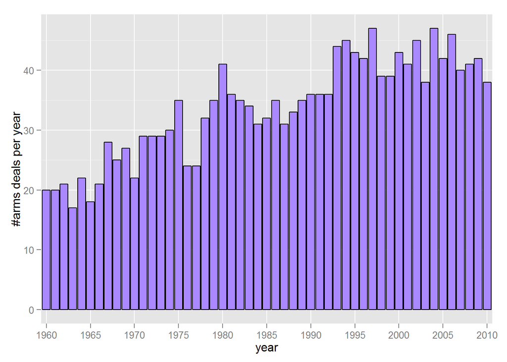

```r
library(ggplot2)
qplot(data = armsFinal, x = year,
      color = I('black'), fill = I('#aa88ff'),
      xlab = 'year', ylab = '#arms deals per year') +
  scale_x_discrete(breaks = seq(1960, 2011, 5))
```

Response: Both country and year are factors while deal size is not

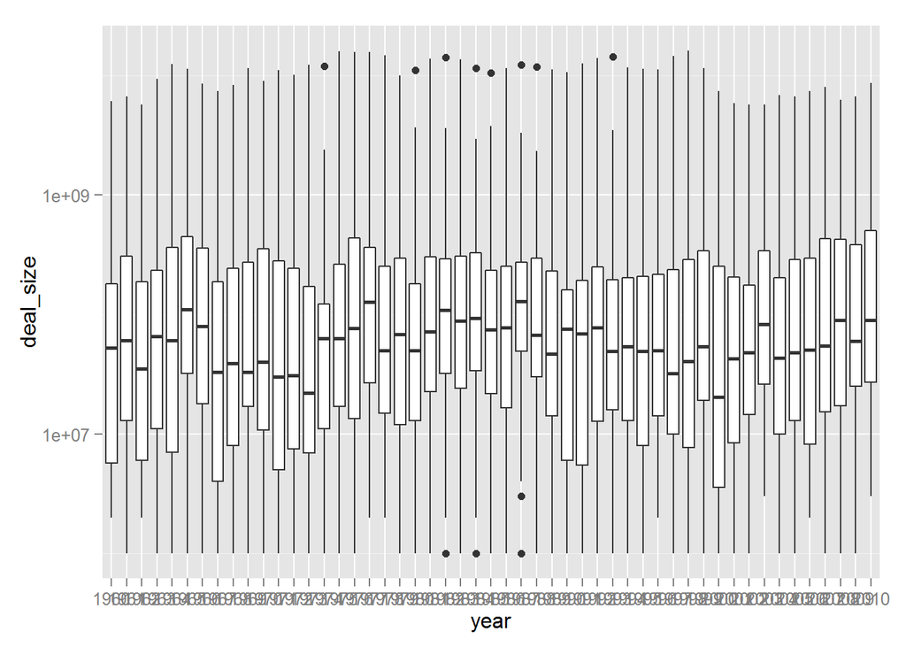

```r
# Convert deal size to logarithmic to better view box plots
qplot(data = armsFinal, y = deal_size, x = year,
      geom = 'boxplot') +
#  coord_cartesian(ylim = c(0, 500000000)) +
  scale_y_log10()
```

Response: Wide variation in deal sizes over the years. However, we don’t see the trend in median increasing deal sizes, so safe to conclude that its somewhat constant

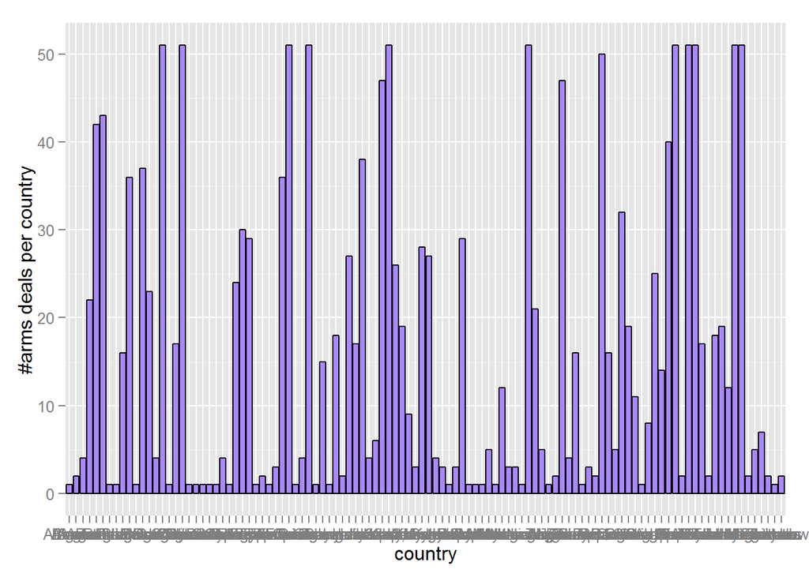

```r
# Too many to view in one graph
qplot(data = armsFinal, x = country,
      color = I('black'), fill = I('#aa88ff'),
      xlab = 'country', ylab = '#arms deals per country')
```